# Лабораторная работа №5

Имитационное Моделирование

Лисенков Е.Р.

Российский университет дружбы народов, Москва, Россия

# Информация

## Докладчик

- Лисенков Егор Романович
- студент
- Российский университет дружбы народов
- 1132232881@rudn.ru
- https://github.com/erlisenkov

# Вводная часть

## Актуальность

Сети Петри предоставляют строгий математический аппарат для анализа параллельных и асинхронных систем, позволяя выявлять критические состояния вроде взаимных блокировок.

## Объект и предмет исследования

Объектом является классическая задача синхронизации «Обедающие философы», а предметом — моделирование её динамики и предотвращение deadlock с помощью сетей Петри.

## Цели и задачи

Целью работы выступает построение и анализ сетей Петри для классической модели и модели с арбитром, а задачами — обнаружение deadlock и генерация отчётной документации.

## Материалы и методы

Исследование выполнено в среде Fedora Linux с использованием языка Julia, пакетов OrdinaryDiffEq и Plots, а также фреймворка DrWatson для управления проектом.

## Установка пакетов для моделирования

Установлены пакеты OrdinaryDiffEq, Plots, DataFrames и Literate для численного моделирования, визуализации и литературного программирования.

[figure not shown]

## Реализация структуры сети Петри

Разработана структура PetriNet и функция build_classical_network для автоматической генерации позиций и переходов классической сети.

[figure not shown]

## Разработка скрипта базового эксперимента

Создан скрипт dining_philosophers.jl, запускающий стохастическую симуляцию и проверяющий наличие deadlock для сетей с арбитром и без него.

[figure not shown]

## Выполнение базового эксперимента

Успешный запуск симуляции подтвердил наличие deadlock в классической сети и его отсутствие в сети с арбитром.

[figure not shown]

## Создание утилиты tangle.jl

Написана утилита на базе Literate.jl для автоматической генерации чистого кода, Quarto-документов и Jupyter Notebooks из литературных скриптов.

[figure not shown]

## Разработка скрипта анимации

Создан скрипт dining_philosophers_animation.jl, визуализирующий изменение маркировки сети Петри во времени в формате GIF.

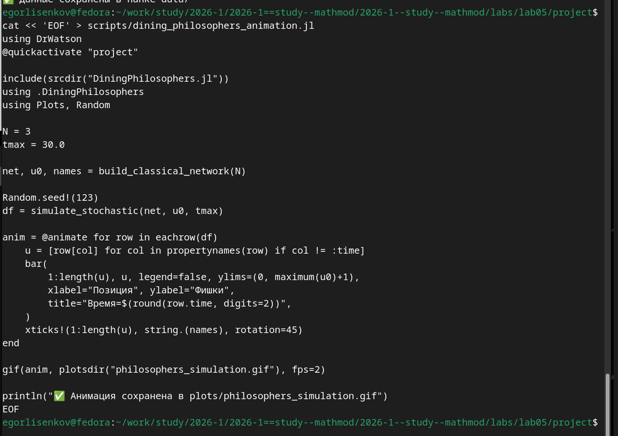

## Генерация анимации модели

Успешно сгенерирован файл philosophers_simulation.gif, наглядно демонстрирующий динамику перемещения фишек между позициями.

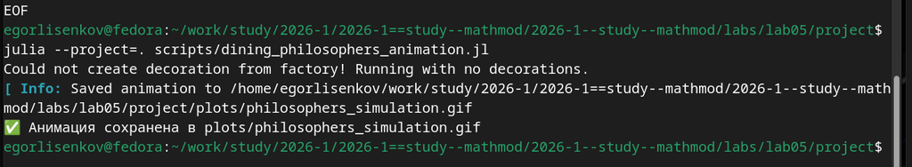

## Создание скрипта итогового отчёта

Разработан скрипт dining_philosophers_report.jl для сравнительного анализа состояния «Ест» в классической сети и сети с арбитром.

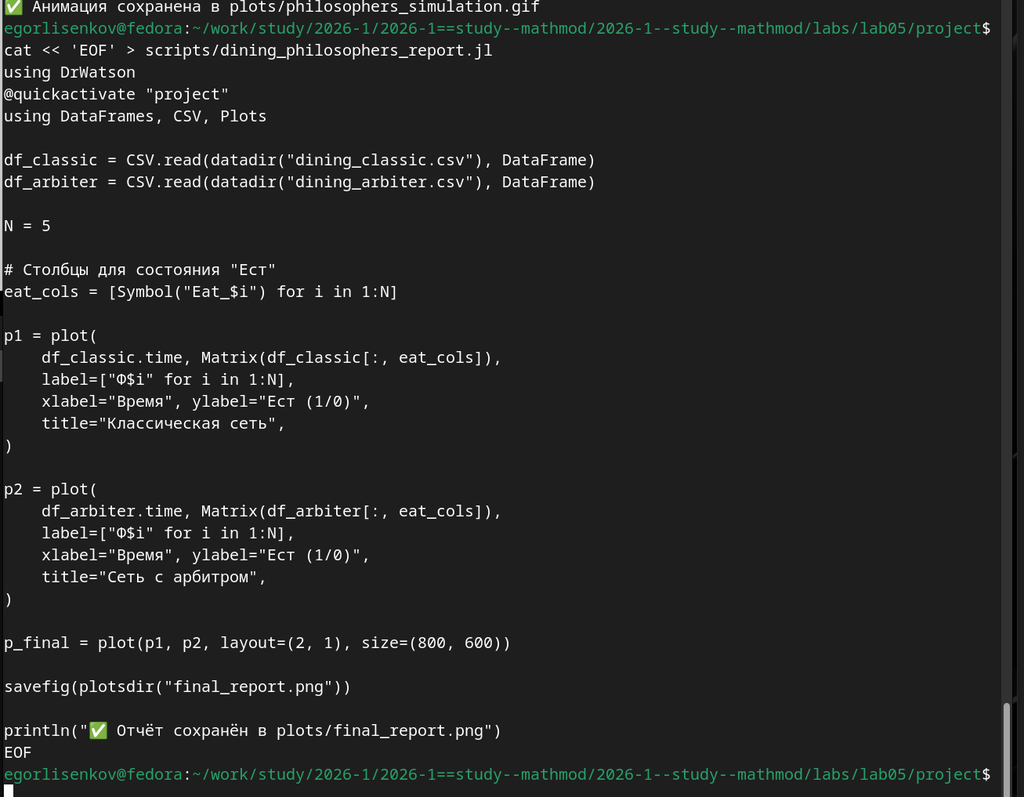

## Выполнение скрипта отчёта

Сгенерирован сравнительный график final_report.png, иллюстрирующий эффект арбитра и предотвращение взаимной блокировки.

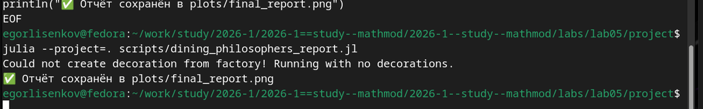

## Формирование литературного скрипта

Создан файл 01_dining_philosophers.jl, объединяющий исполняемый код базового эксперимента и Markdown-описания.

[figure not shown]

## Генерация производных форматов

Утилита tangle.jl автоматически преобразовала литературный скрипт в чистый код, Quarto-документ и Jupyter Notebook.

[figure not shown]

## Создание параметрического скрипта

Разработан скрипт 02_dining_philosophers_param.jl для систематического сканирования комбинаций параметров N, tmax и seed.

[figure not shown]

## Запуск параметрического исследования

Инициирован перебор 12 комбинаций параметров с отслеживанием статуса обработки каждого эксперимента.

[figure not shown]

## Завершение параметрического исследования

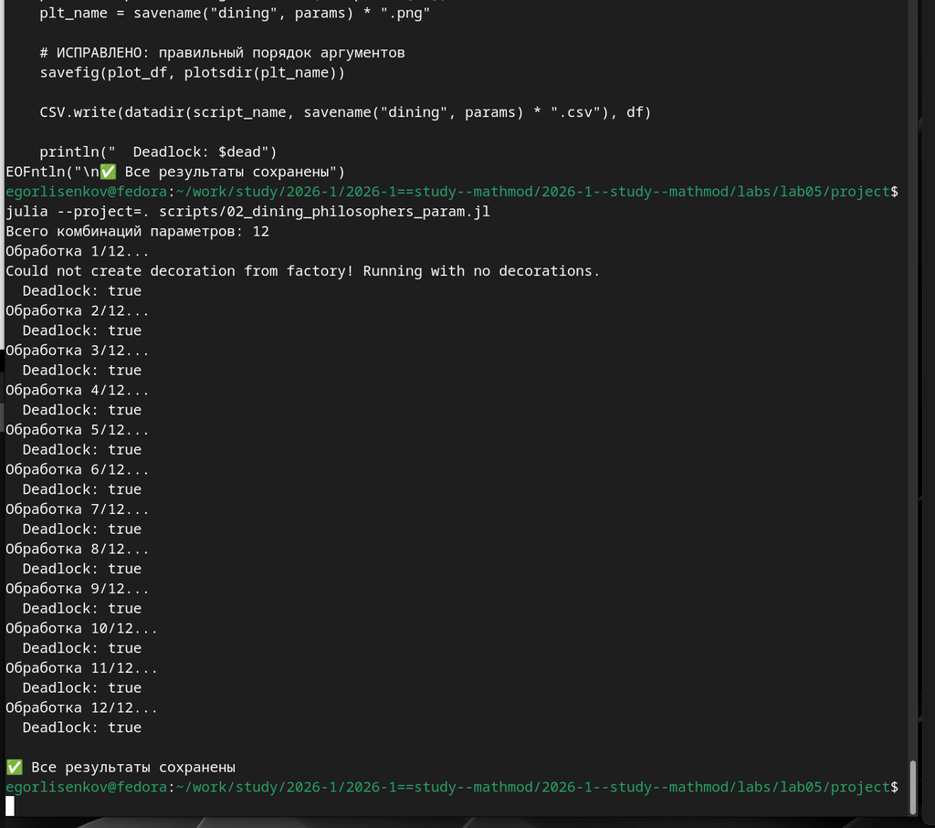

## Финальная верификация проекта

Проверка структуры каталогов подтвердила наличие 16 графических артефактов и всех необходимых производных форматов кода.

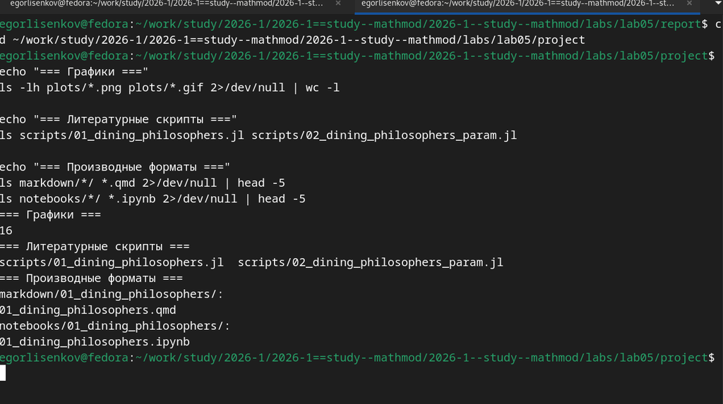

# Результаты

# Выводы

В результате проделанной работы были освоены фундаментальные принципы моделирования дискретных событийных систем с помощью аппарата сетей Петри. Практически подтверждено, что сети Петри предоставляют строгий формальный аппарат для анализа параллельных процессов: матрица инцидентности однозначно задаёт структуру сети, алгоритм Гиллеспи позволяет проводить стохастическое моделирование с корректным учётом вероятностей срабатывания переходов, а функция detect_deadlock даёт алгоритмический способ верификации отсутствия взаимных блокировок.